# PlayStudios - analyzing video data

Ilona Zaslavsky

February 2020

## Background

The Head of Product has identified as a major problem for the site a very high home page drop-off rate. That is, users come to the home-page and then leave the site without taking any action or watching any video.  
Since customer acquisition costs are very high, this is a huge problem: the company is spending a lot of money to acquire users who don’t generate any revenue. This company is interested in knowing whether a video is “hot” , stable or going down.  
Understanding this would allow to optimize the videos promoted on the home-page and, therefore, maximize ads revenue.

### The purpuse of the task

- Classifing each video to one of the three categories:  
  – “Hot Videos”  
  – “Stable and Popular Videos”  
  – “Everything else”
- Find the main characteristics of the “hot videos”

### Actions:

– Look at the `video_count` data  
– Define each category  
– Classify each video to a category (using mine model or known model)  
– Look at the `video_features` data  
– Find correlated variables  
– Find main characteristics of the “hot videos”

## Load the `video_count` data and explore it

In the data we have 11903 observations for 100 videos.

The variables are: video_id, date, count.  
To work on the variables I had to change the type of the `date` from factor to date.

glimpse to ‘video_count’ data

| video_id | date | count |
| --- | --- | --- |
| 56 | 2017-12-23 | 33 |
| 96 | 2017-12-15 | 58 |
| 100 | 2017-12-04 | 114 |
| 32 | 2017-12-25 | 18 |
| 79 | 2017-10-17 | 46 |
| 43 | 2017-11-03 | 98 |

summary of ‘video_count’

|  | video_id | date | count |
| --- | --- | --- | --- |
|  | Min. : 1.00 | Min. :2017-09-03 | Min. : 6.00 |
|  | 1st Qu.: 25.00 | 1st Qu.:2017-10-31 | 1st Qu.: 51.00 |
|  | Median : 50.00 | Median :2017-11-30 | Median : 72.00 |
|  | Mean : 50.49 | Mean :2017-11-30 | Mean : 75.43 |
|  | 3rd Qu.: 76.00 | 3rd Qu.:2017-12-30 | 3rd Qu.: 97.00 |
|  | Max. :100.00 | Max. :2018-02-27 | Max. :196.00 |

Each video is shown on the home page for 121 days. However, for some videos there weren’t views every day.  
To deal with this I added the value *zero* under the ‘count’ to the missing dates of the relevant videos.  
After this, we get count of views for each video over all the 121 days.  
The mean of the ‘count’ changed to 74.21 and the median stayed 72.

## Define each category

The definition of ‘hot video’ category will be defined by weighting the **number of views** for each video and a **steady trend** of views over 121 days.

### Count total views and average views for each video

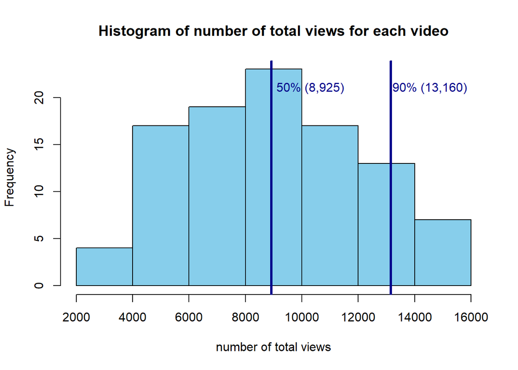

### Calculate the linear regression’s slope

The idea is to check the trend of the videos over the days.  
I’ll use the linear regression analysis to quantify the strength of the relationship between the dates and the count of views, and use the regression’s slope to see the stability of the count of views.  
**When the slope is negative:** The more positive the slope (closer to 0) the relatively stable its trend.

Here is an example for video which monitored for 121 days. We see the count of views every day and the linear regression line.

We see that the video has decreasing trend of views (negative slope) but roughly stable till the end of the 121 days.

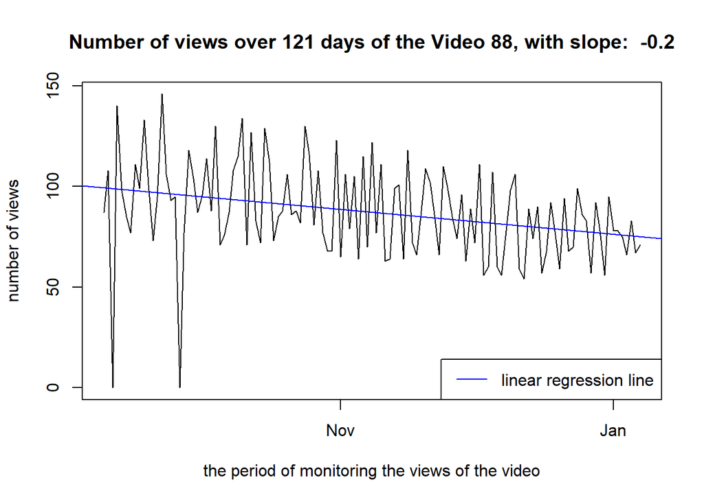

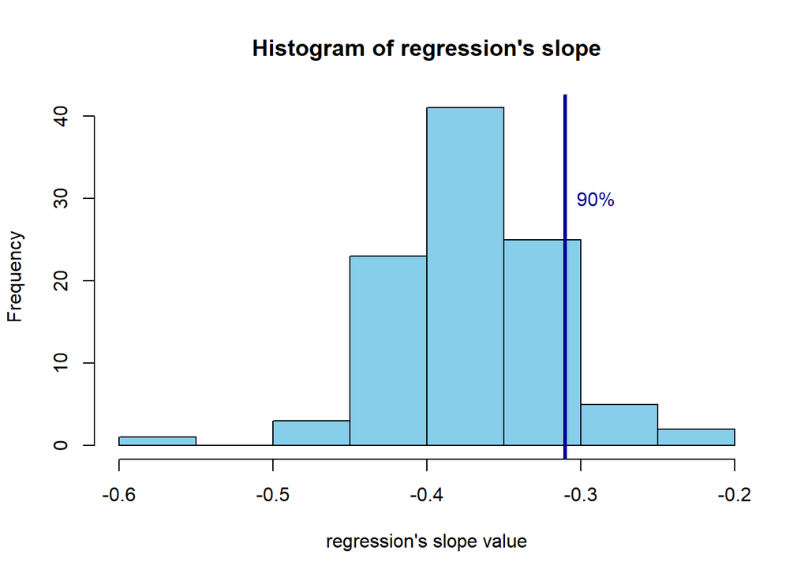

Looking at the histogram we see that all the videos have a negative trend, and most of the videos have slope between -0.3 to -0.4.5.

### summarizing the variables:

|  | video id | regression slope | count of views | mean of views |
| --- | --- | --- | --- | --- |
|  | Min. : 1.00 | Min. :-0.5600 | Min. : 3454 | Min. : 28.55 |
|  | 1st Qu.: 25.75 | 1st Qu.:-0.4025 | 1st Qu.: 6426 | 1st Qu.: 53.11 |
|  | Median : 50.50 | Median :-0.3600 | Median : 8925 | Median : 73.76 |
|  | Mean : 50.50 | Mean :-0.3661 | Mean : 8978 | Mean : 74.21 |
|  | 3rd Qu.: 75.25 | 3rd Qu.:-0.3400 | 3rd Qu.:11360 | 3rd Qu.: 93.88 |
|  | Max. :100.00 | Max. :-0.2000 | Max. :15909 | Max. :131.48 |

## Choosing a model

After showing the distribution and the characteristics of each varieble I can use any clustering model like the ‘K-means’ madel to classify the categories.  
However, in my opinion the ‘K-means’ madel didn’t consider the best the importance of the regressions slope (the variable that represent the stability of the trend of viewing the videos).

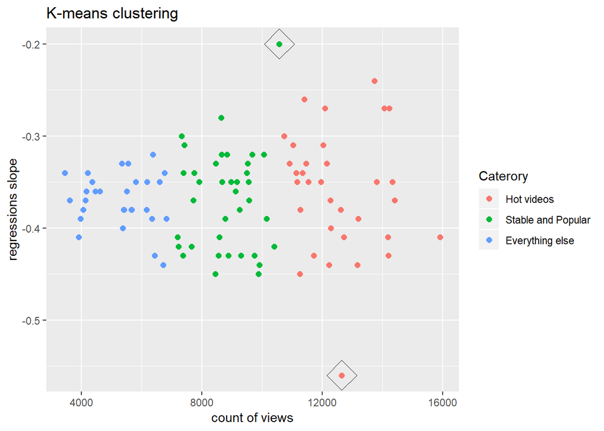

Looking at the classified three groups, I marked two points that I would change their classifying.  
– The ‘hot video’ that marked has an outlier big slope. Even though the number of views was high, the trend of the views shows that it went down fast. Means, the video lost its relevance to the end of the 121 days period.  
– The second point I marked has less total views, but the slope shows a steady trend of views over the 121 days. I would say that this is a “hot video” because it has steady trend of views, and still big amount of views.

Looking at this, I was convinced that count of views is an influencing variable, but also the slope variable, that shows how much the trend of views is steady.

Another issue that I’m not agree with the K-means model, is that the number of obserations in the categories almost equal.  
Later, I would like to give main characteristics of the “hot videos”. To do this I’d like to make this category smaller to minimize the variance inside the group.

#### In conclusion of this issue, the solutions I suggest are:

- Normalize the variables and give them Weight.
- Choose the representation part of every videos category.

### The result:

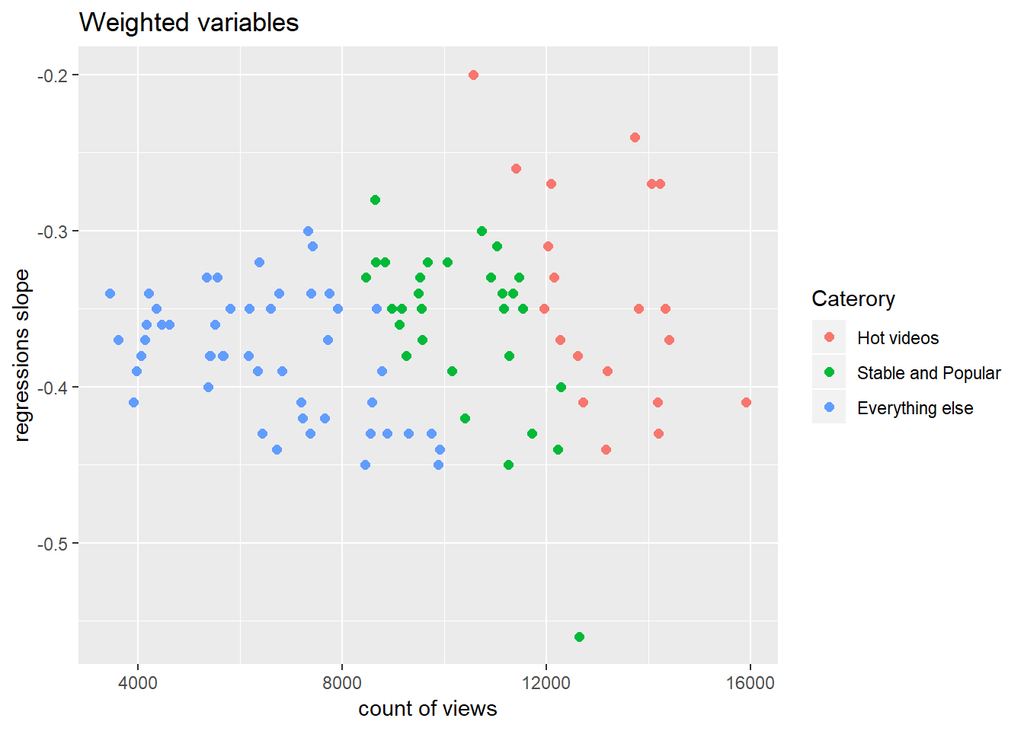

- ‘count of views’ got Weighting of 0.8, and the linear regression slope got the 0.2 Weight. The points I analysed before got their corrected category.
- The hot videos represent top 20 videos that got the best rank after Weighting the variebles. The “everything else” category represent first 50 of the data with the smallest rank, and the videos under the ‘Stable and Popular’ category got the rank between thoes two categories (30 videos).

## Find characteristics from the `video features` data

After categorizing each video, I’ll check the features of each category and find the the characteristics of the “hot videos”.

**First, summary the video features:**

|  | video_id | video_length | video_language | video_upload_date | video_quality |
| --- | --- | --- | --- | --- | --- |
|  | Min. : 1.00 | Min. :15.0 | chineese:35 | Min. :2017-09-03 | 1080p:16 |
|  | 1st Qu.: 25.75 | 1st Qu.:19.0 | english :33 | 1st Qu.:2017-09-17 | 240p :16 |
|  | Median : 50.50 | Median :23.0 | spanish :32 | Median :2017-09-29 | 360p :23 |
|  | Mean : 50.50 | Mean :22.7 | NA | Mean :2017-10-01 | 480p :28 |
|  | 3rd Qu.: 75.25 | 3rd Qu.:27.0 | NA | 3rd Qu.:2017-10-13 | 720p :17 |
|  | Max. :100.00 | Max. :30.0 | NA | Max. :2017-10-30 | NA |

Now, let’s see the distribution of the quality of the video and the length of the videos parted by the categories:

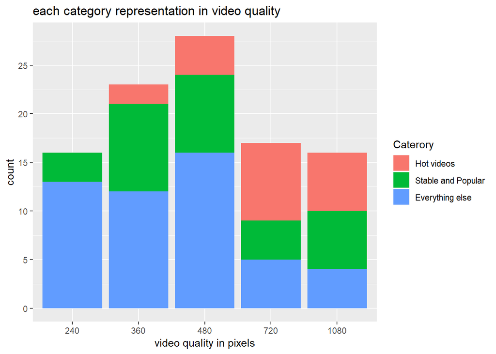

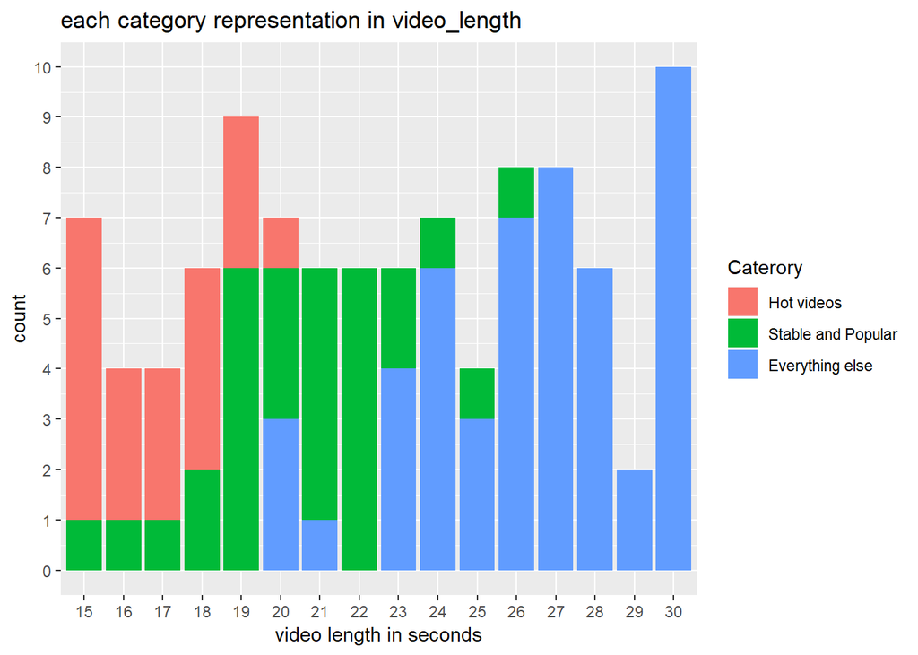

### Conclusions:

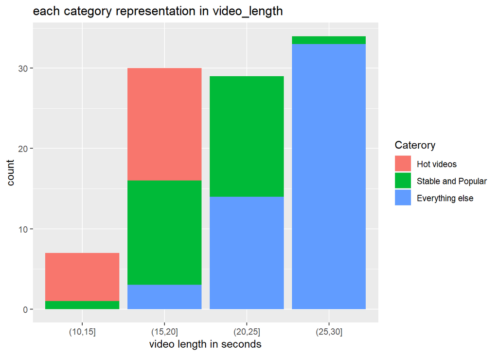

Now, I test the hypothesis whether videos’ category is independent of:  
* the length of the video  
* the quality of the video  
* the language of the video  
at 0.05 significance level.

I apply the chisq.test function to the contingency tables, and found the p-values are:

| video category indipendent to | P-value | reject the null hypotisis |
| --- | --- | --- |
| factored length of the video | 1.538078410^{-15} | TRUE |
| quality of the video | 0.0040013 | TRUE |
| language of the video | 0.9543845 | FALSE |

As the p-value is smaller than the 0.05 significance level, we do reject the null hypothesis that the category of the video is independent of the video’s length and quality.  
We do not reject the null hypothesis that the category of the video is independent of the video’s language.

## – The bottom line –

The main characteristics of the “hot videos” are the length of the video (the shorter the better) and the quality of the video (‘hot videos’ are in good quality).  
I’ll use this information to suggest the head of product publish short (till 20 seconds) videos and with good quality (720p and better) in the “hot spots” of the page in the site (top page).  
I believe that this information would allow to optimize the videos promoted on the home-page and, therefore, maximize ads revenue.

### Last word

**More research questions that I asked and didn’t answer on them:**  
* What is the recommended time for the videos to be uploaded and seen. in other words, when do we have the biggest amount of watchers? (what days, what month, what period of the year?)  
* The information on the video’s issue was missing and obviously this also affects on the results of the data analysis.  
* The information of the possition of the video in the site(top page, bottom page) also affects on the results.

*Thanks for reading my research. I’m open to any feedback*

–THE END–